# Black-Owned Businesses in Northeast Los Angeles

## A Story of Excellence Despite Underinvestment

1. Introduction
   1. Scope of Research
   2. Languages and Tools Used
2. Setup
   1. Getting the Yelp Fusion API Key
   2. Setting Up the Environment
3. Phase One: Data Collection
4. Phase Two: Data Wrangling
   1. Yelp Data
   2. BWDC Data
5. Phase Three: Data Visualization and Analysis
   1. Conclusions
6. Bonus: Mapping Black Businesses in NELA

## Introduction

This document details my research into the story of Black-owned businesses in Northeast Los Angeles. In order to uncover this story, I gathered data via the [Yelp Fusion API](https://fusion.yelp.com/) and from [Black Wealth Data Center](https://blackwealthdata.org/).

### Scope of Research

I live in Los Angeles, which is a big place. More specifically, I live in Northeast Los Angeles (NELA), a region of the city that has a rich and diverse history. My neighborhood, Highland Park, has faced long-standing racial tensions that have historically made it unsafe for many Black families to live here. Fortunately, this reality is beginning to change, which sparked my curiosity:

*What is the current state of Black-owned businesses in Northeast LA?*

To answer this question, I used the Yelp Fusion API to focus on zip codes in and around NELA. While some results fell outside the region due to how Yelp handles distance, most of the businesses analyzed are located within NELA.

### Languages and Tools Used

The recommended languages and tools for this challenge included Python, SQL, Google Looker, and GitHub.

I chose Python for its widespread use in data science and its extensive library ecosystem for data analysis and visualization.

Instead of Google Looker, I opted to work in a JupyterLab Notebook. JupyterLab is an excellent tool for data science prototyping, offering several advantages:

- It allows for seamless integration of markdown text and code. This means users can embed contextual information and human-readable analysis alongside their code in a clear and organized way.
- JupyterLab is an industry-standard tool in data science, particularly in academic and research settings.
- As a curriculum developer, I was interested in exploring JupyterLab as a potential tool for creating student guides.

While I have years of experience with SQL, I did not use it for this project. Instead, I relied on the `pandas` library in Python. `pandas` provides powerful data wrangling capabilities and uses a data structure approach similar to relational databases.

Lastly, although I am not hosting my code directly on GitHub, this HTML document is hosted via GitHub for online access.

Other Python libraries I used include:

- `requests` to make HTTP requests to the Yelp Fusion API.
- `matplotlib` to visualize data via graphs.
- `folium` to create an interactive map via the `Leafleat.js` JavaScript library. `folium` acts as a Python wrapper around that library, enabling Python users to leverage it.

## Setup

### Getting the Yelp Fusion API Key

In order to make calls to the Yelp Fusion API, I needed to make an account, create an app under that account, and obtain an API key.

In general, API keys ought to be kept somewhere safe, such as AWS Secrets Manager. They should not appear in the app code.

However, in the spirit of prototyping, I will simply add the API key I used here and then cycle my key before publishing this document so that this key can no longer be used:

```python
yelp_api_key = "HvQFpO5OxSCDuvSOs6BwQAE6oWnuon3e32YaPdj2kd6tuiORZ9HcnUFVbeoDydL8SQVhbjN8IX1INE1OcPnKM-ap3AsMWmmekhXLXxKrbmxBMweDyojactsItF1HZ3Yx"
```

### Setting Up the Environment

Requirements for this project include:

- Python 3.6 or higher
- [JupytperLab](https://jupyter.org/) Notebooks
- Installing Python libraries e.g. via `conda install` in the JupyterLab Notebook (omitted from this project)

## Phase One: Data Collection

Let's begin the coding portion of this project by pulling data on Black-owned businesses in NELA from the Yelp Fusion API. In order to do this, we need to be able to:

- Make HTTP requests to the API.
- Page through results from the API.
- Collect and retain data as we page through.
- Save the data to a local file in case we want to use it later, so that we don't have to gather it again.

First, let's work on a function that can make an HTTP GET request to the Yelp Fusion API.

A few imports and values necessary to access the API:

```python
import requests
import json
from urllib.parse import urlencode

yf_business_search_url = f"https://api.yelp.com/v3/businesses/search"

headers = {
  "accept": "application/json",
  "Authorization": f"Bearer {yelp_api_key}"
}
```

Psuedocode for the request function:

```
- take in three arguments: search parameters, response size limit, and pagination offset

- create the query parameter list via a safe url encoder

- make the request

- if the response contains an error code, raise an exception

- else return the response
```

```python
def send_get_request(search_params: dict, limit: int, offset: int) -> requests.Response:
    """
    Sends an HTTP GET request containing the given search parameters,
    limit, and offset to the Yelp Fusion API.
    """
    query_params = search_params.copy()
    query_params.update({'limit': limit, 'offset': offset})
    response = requests.get(yf_business_search_url, headers=headers, params=query_params)
    response.raise_for_status()  # Raise an exception for HTTP errors
    return response
```

Next, let's write the function that will page through the results, gather them into a ```pandas`` dataframe, and write them to a file.

Here is some psuedocode for the function:

```
create a dataframe where we will store results as we get them

for each zip code in NELA:

    until there are no more results:

        - get 40 results and save them to a pandas dataframe

        - if we get fewer than 40, stop here, because we have reached the end of the results

        - else if we have already gathered 240 results from this search, stop here, because the API will not return more than the first 240 results from a given search.

        - else if we get an error message, stop, report it, and save what we have so far to a file.

        - else, get the next 40 results
```

The function also includes some basic error handling and logging in case the HTTP response was not in the 200 range.

I chose 40 as the page size to make it easier to handle the 240 result limitation; the maximum page size is 50, but since 40 divides 240 evenly, it's simpler to stop where we should.

I want to compare ratings for Black-owned businesses in NELA to all businesses in NELA, so we'll call this function twice: once to search for the term "Black-owned businesses" and once with an empty search term.

```python
import pandas as pd
import matplotlib

def get_businesses(term: str, file_name: str) -> pd.DataFrame:
    """
    Pages through results in NELA from the Yelp Fusion API for the given
    search term. Saves results to the given file_name as a CSV.
    """
    # Initialize an empty DataFrame to store results
    results_df = pd.DataFrame()

    nela_zip_codes = ["90031", "90032", "90041", "90042", "90065", "91204", "91205"]

    for zip in nela_zip_codes:
        # Paging variables
        offset = 0
        limit = 40

        while True:
            try:
                search_params = {
                    'location': zip,
                    'term': term
                }


                # Call the GET request function we wrote above
                print(f'Getting {limit} results with offset {offset} for zip code {zip}')
                response = send_get_request(search_params, limit, offset)

                # Parse the JSON response, pulling out the `businesses` field, which contains a list of businesses
                businesses = response.json().get("businesses", [])

                # If no businesses are returned, stop the loop
                if not businesses:
                    break

                # Append the results to the DataFrame
                results_df = pd.concat([results_df, pd.DataFrame(businesses)], ignore_index=True)

                # If fewer than 50 results are returned, or we have reached 240 results, stop the loop
                if len(businesses) < limit or offset >= 200:
                    break

                # Increment the offset for the next API call
                offset += limit

            except Exception as e:
                # Save the DataFrame to a file in case of an error
                print(f"An error occurred: {e}")
                results_df.to_csv(file_name, index=False)
                return results_df

    # Save the final results to a file
    results_df.to_csv(file_name, index=False)
    return results_df
```

Now, let's call it:

```python
print("Getting Black-owned businesses in NELA")
black_businesses_df = get_businesses("Black owned", "./nela_black_owned_businesses.csv")

print("Getting all businesses in NELA")
all_businesses_df = get_businesses("", "./nela_all_businesses.csv")
```

```
Getting Black-owned businesses in NELA
Getting 40 results with offset 0 for zip code 90031
Getting 40 results with offset 40 for zip code 90031
Getting 40 results with offset 80 for zip code 90031
Getting 40 results with offset 120 for zip code 90031
Getting 40 results with offset 160 for zip code 90031
Getting 40 results with offset 200 for zip code 90031
Getting 40 results with offset 0 for zip code 90032
Getting 40 results with offset 40 for zip code 90032
Getting 40 results with offset 80 for zip code 90032
Getting 40 results with offset 120 for zip code 90032
Getting 40 results with offset 160 for zip code 90032
Getting 40 results with offset 200 for zip code 90032
Getting 40 results with offset 0 for zip code 90041
Getting 40 results with offset 40 for zip code 90041
Getting 40 results with offset 0 for zip code 90042
Getting 40 results with offset 40 for zip code 90042
Getting 40 results with offset 80 for zip code 90042
Getting 40 results with offset 0 for zip code 90065
Getting 40 results with offset 40 for zip code 90065
Getting 40 results with offset 80 for zip code 90065
Getting 40 results with offset 120 for zip code 90065
Getting 40 results with offset 160 for zip code 90065
Getting 40 results with offset 200 for zip code 90065
Getting 40 results with offset 0 for zip code 91204
Getting 40 results with offset 40 for zip code 91204
Getting 40 results with offset 80 for zip code 91204
Getting 40 results with offset 0 for zip code 91205
Getting 40 results with offset 40 for zip code 91205
Getting 40 results with offset 80 for zip code 91205
Getting all businesses in NELA
Getting 40 results with offset 0 for zip code 90031
Getting 40 results with offset 40 for zip code 90031
Getting 40 results with offset 80 for zip code 90031
Getting 40 results with offset 120 for zip code 90031
Getting 40 results with offset 160 for zip code 90031
Getting 40 results with offset 200 for zip code 90031
Getting 40 results with offset 0 for zip code 90032
Getting 40 results with offset 40 for zip code 90032
Getting 40 results with offset 80 for zip code 90032
```

[output cut: 17 more lines]

```
Getting 40 results with offset 120 for zip code 90065
Getting 40 results with offset 160 for zip code 90065
Getting 40 results with offset 200 for zip code 90065
Getting 40 results with offset 0 for zip code 91204
Getting 40 results with offset 40 for zip code 91204
Getting 40 results with offset 80 for zip code 91204
Getting 40 results with offset 120 for zip code 91204
Getting 40 results with offset 160 for zip code 91204
Getting 40 results with offset 200 for zip code 91204
Getting 40 results with offset 0 for zip code 91205
Getting 40 results with offset 40 for zip code 91205
Getting 40 results with offset 80 for zip code 91205
Getting 40 results with offset 120 for zip code 91205
Getting 40 results with offset 160 for zip code 91205
Getting 40 results with offset 200 for zip code 91205
```

Now, let's load up some data from BWDC. I downloaded a CSV on Covid-era Paycheck Protection Loans distribution among racial groups. The data can be found here: https://blackwealthdata.org/explore/business#BOW-04

It includes data at different geographic levels, such as state, county, and zip code, for all of the United States, so we will have a lot of filtering to do in step 2.

```python
loans_df = pd.read_csv("loans.csv")
```

## Phase Two: Data Wrangling

### Yelp Data

Let's clean up our Yelp data first. Although we're not yet at the data visualization and analysis step, getting some basic statistics from the data sets will be helpful.

```python
def print_statistics(df, title):
    count = len(df)
    mean_rating = df['rating'].mean()
    median_rating = df['rating'].median()
    std_rating = df['rating'].std()

    print(f"STATISTICS: {title}")
    print(f"Count: {count}")
    print(f"Mean Rating: {mean_rating}")
    print(f"Median Rating: {median_rating}")
    print(f"Standard Deviation: {std_rating}")
    print("\n")

print_statistics(black_businesses_df, "Black NELA Business Ratings")
print_statistics(all_businesses_df, "General NELA Business Ratings")
```

```
STATISTICS: Black NELA Business Ratings
Count: 1114
Mean Rating: 3.9106822262118492
Median Rating: 4.9
Standard Deviation: 1.818869568247423


STATISTICS: General NELA Business Ratings
Count: 1625
Mean Rating: 4.164369230769231
Median Rating: 4.3
Standard Deviation: 0.7643967076321551
```

Looking into the numbers a bit more, it seems like many or all of the 0 star ratings are for businesses that have no reviews at all. These outliers might be skewing our statistics. Let's exclude any businesses with fewer than 2 reviews from the dataset.

```python
black_businesses_df_clean = black_businesses_df[black_businesses_df['review_count'] >= 2]
all_businesses_df_clean = all_businesses_df[all_businesses_df['review_count'] >= 2]

print_statistics(black_businesses_df_clean, "Black NELA Business Ratings")
print_statistics(all_businesses_df_clean, "General NELA Business Ratings")
```

```
STATISTICS: Black NELA Business Ratings
Count: 748
Mean Rating: 4.658422459893048
Median Rating: 4.9
Standard Deviation: 0.48365096681495


STATISTICS: General NELA Business Ratings
Count: 1573
Mean Rating: 4.252447552447553
Median Rating: 4.3
Standard Deviation: 0.450164711814211
```

A lot of businesses from the Black-owned businesses set were excluded! This should be more reflective of the actual average customer satisfaction for the businesses in these data sets.

### BWDC Data

Now let's move on to cleaning up the BWDC data. This is a much more complicated data set. There are multiple rows for any given geographic region cut along features like gender and veteran status. Happily, there are rows where these features are listed as "All", so we can just keep those rows.

We also want to only look at the NELA zip codes, so we'll delete the rest of the rows.

Finally, we will filter out rows where race and ethnicity are set to "other" or "total."

```python
nela_zip_codes = ["90031", "90032", "90041", "90042", "90065", "91204", "91205"]

loans_df_clean = loans_df[
    (loans_df['geo_level'] == 'zip') & (loans_df['geo_name'].isin(nela_zip_codes)) & (loans_df['gender'] == 'All') & (loans_df['veteran'] == 'All')
]

# Filter out "Other" and "Total" categories from the race/ethnicity column
loans_df_clean = loans_df_clean[~loans_df_clean['race_or_ethnicity'].isin(['Other', 'Total'])]

## Get rid of these columns, since we've only kept the rows where they're equal to 'All`
loans_df_clean = loans_df_clean.drop(labels = ['gender', 'veteran'], axis = 1)
print(loans_df_clean)
```

```
        geo_name geo_level race_or_ethnicity  number_of_loans  loan_amount  \
153291     90032       zip             Black               27     413571.0
198737     90041       zip             White              113    6024661.0
201014     90042       zip          Hispanic              123    7147101.0
359462     91204       zip             Black               19     416861.0
433941     90065       zip             White              203   17227789.0
574277     90031       zip             Black               16     286620.0
575595     90065       zip             Black               17     357530.0
620472     91204       zip             Asian               61    3514097.0
815709     91205       zip          Hispanic               29    1062586.0
852375     90042       zip             Asian               89    3597741.0
858198     90041       zip             Asian              109    4028820.0
1029102    91205       zip             Black               24    2056581.0
1036439    90042       zip             Black               29     536942.0
1062871    90041       zip          Hispanic               65    4060023.0
```

[output cut: 74 more lines]

## Phase Three: Data Visualization and Analysis

Let's begin with visualizing our Yelp data with a couple of ratings histograms. We will write a function and then call it for each of the dataframes we captured from the Yelp data.

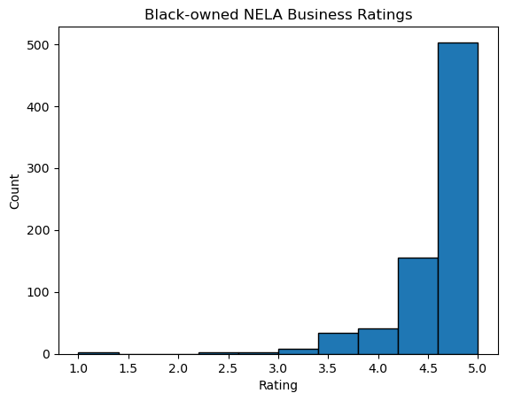

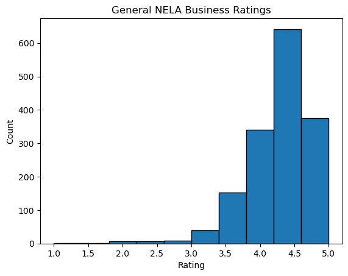

```python
from matplotlib import pyplot as plt

def make_histogram(df, title):
    # Plot a histogram for the ratings
    plt.hist(df['rating'].dropna(), bins=10, edgecolor='black')
    plt.title(title)
    plt.xlabel('Rating')
    plt.ylabel('Count')
    plt.show()

make_histogram(black_businesses_df_clean, 'Black-owned NELA Business Ratings')
make_histogram(all_businesses_df_clean, 'General NELA Business Ratings')
```

The data indicates that, on average, Black-owned businesses are better-received by their patrons than businesses in general in NELA. The data does not yet clearly tell us why that is, but it seems that there is a trend of excellence among these businesses.

Now, let's visualize the BWDC data.

Each row in our cleaned data set represents the data for a given zip code and racial group.

I want to plot two values for each racial/ethnic group in the dataset:

- Respective loan count share (% of total loans granted)
- Respective loan amount share (% of total money distributed)

In order to do that, we will:

1. Calculate the loan count and amount share for each row in the dataset.
2. Group the rows by racial/ethnic group and sum their loan count and amount shares, respectively.
3. Create a comparison Dataframe, which is a multidimensional dataframe containing the data cut along our target measures.
4. Plot the histogram.

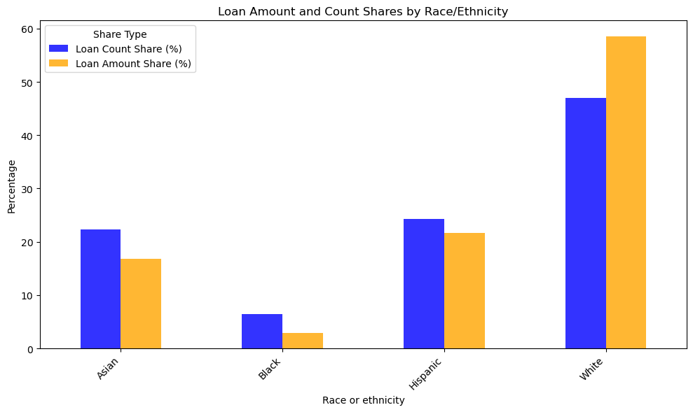

```python
# Calculate loan count and amount share for each row in the dataset
loans_df_clean['loan_count_share'] = (loans_df_clean['number_of_loans'] / loans_df_clean['number_of_loans'].sum()) * 100
loans_df_clean['loan_amount_share'] = (loans_df_clean['loan_amount'] / loans_df_clean['loan_amount'].sum()) * 100

# Calculate loan shares by racial group by summing on that feature
racial_loan_count_share = loans_df_clean.groupby('race_or_ethnicity')['loan_count_share'].sum()
racial_loan_amount_share = loans_df_clean.groupby('race_or_ethnicity')['loan_amount_share'].sum()

# Create comparison DataFrame
comparison_df = pd.DataFrame({
    'Loan Count Share (%)': racial_loan_count_share,
    'Loan Amount Share (%)': racial_loan_amount_share,
}).reset_index() # Call reset_index() to reset to the original df's index, as this is now a multindex / multidimensional df

# Plot histogram
comparison_df.set_index('race_or_ethnicity', inplace=True)
comparison_df.plot(kind='bar', figsize=(10, 6), alpha=0.8, color=['blue', 'orange'])

# Add labels and title
plt.ylabel('Percentage')
plt.xlabel('Race or ethnicity')
plt.title('Loan Amount and Count Shares by Race/Ethnicity')
plt.xticks(rotation=45, ha='right')
plt.legend(title='Share Type', loc='upper left')

# Show the plot
plt.tight_layout()
plt.show()
```

### Conclusions

As you can see, Black-owned businesses in NELA received far fewer total loans and far less total monetary aid from the Paycheck Protection Program Loan program than any other group.

Given that Black-owned businesses have such high ratings relative to all businesses in NELA, this raises the question: *why do these businesses seem to receive less public investment and protection?*

Without additional population and business ownership data, we cannot yet draw firm conclusions about why this is. However, a story is beginning to emerge about Black business excellence despite under-investment from public funds.

Future research should include these questions:

- What are the relative population shares of each of these racial groups in NELA?
- What are the relative business ownership shares of each of these racial groups in NELA?
- If Black NELA business owners received proportionately fewer Paycheck Protection Program loans, or smaller amounts on those loans, why is that?
  - Possible answers include: fewer Black business owners applied for loans; loan applications were rejected at higher rates for Black business owners; Black-owned businesses are evaluated as lower need.
  - All of these possible answers have many possible causes behind them.
- What legal, economic, and sociocultural barriers have different racial groups faced when it comes to business ownership in NELA?

## Bonus: Mapping Black Businesses in NELA

As a bonus, let's use the `folium` library to map Black businesses in NELA.

`folium` is a Python wrapper around the JavaScript `Leaflet.js` library. This is a powerful and user-friendly library that allows us to create interactive maps.

```python
import folium

# Load the black-owned businesses dataset
black_owned_df = pd.read_csv('./nela_black_owned_businesses.csv')
black_owned_df = black_owned_df[black_owned_df['review_count'] >= 2]

# Helper function to parse values in the coordinates column (example: "{'latitude': 34.13324, 'longitude': -118.14879}")
def parse_coordinates(coord):
    try:
        coord_dict = eval(coord)
        return (coord_dict['latitude'], coord_dict['longitude'])
    except:
        return None

black_owned_df['coordinates'] = black_owned_df['coordinates'].apply(parse_coordinates)

# Create a base map centered in Northeast LA
nela_map = folium.Map(location=[34.1, -118.2], zoom_start=12)

# Add markers for each black-owned business
for _, row in black_owned_df.iterrows():
    if pd.notna(row['coordinates']):
        folium.Marker(
            location=row['coordinates'],
            popup=f"Business: {row['name']}<br>Rating: {row['rating']}<br>Reviews: {row['review_count']}",
            icon=folium.Icon(color='lightgreen', icon='info-sign')
        ).add_to(nela_map)

# Save and display the map
nela_map.save("nela_black_owned_businesses_map.html")
nela_map
```

Make this Notebook Trusted to load map: File -> Trust Notebook

[interactive chart not shown]